# CourseProject

ENM

May 23, 2018

Load the data sets and create a list with all of them. NOTE: I created the list to simplify the data transformations needed for the models I built. All the original exploratory analysis was performed in the train data set and NOT in the validation or test data set.

```r
train <- read.csv("pml-training.csv")
test <- read.csv("pml-testing.csv")
set.seed(5)
inTrain <- createDataPartition(train$classe, p = .8)[[1]]
validation <- train[-inTrain,]
train <- train[inTrain,]

l_d <- list(train, validation, test)
names(l_d) <- c("train", "validation", "test")
```

Keep only some variables (vars. without missing values and vars. that aren’t summaries of others).

```r
nas <- sapply(train[1:dim(train)[2]], function(x){
      sum(is.na(x))})
nokeep <- c(names(nas[nas != 0]),
            grep(pattern = "^kurtosis|^skewness|^amplitude|^min|^max", colnames(train), value = T))
nokeep <- unique(nokeep)

l_d <- lapply(l_d, function(x){
      keep <- colnames(x) %in% nokeep == 0
      x1 <- x[,keep]
      return(x1)
})
```

After observing a relation between time and classe, I created new variables to explore this relation. Note that in mins_since_1, the starting point is the time of the first try IN THE TRAIN DATA SET.

```r
l_d <- lapply(l_d, function(x){
      x$date_time <- dmy_hm(x$cvtd_timestamp)
      x$time <- paste(hour(x$date_time), minute(x$date_time), sep = ":")
      x$time_n <- as.numeric(x$date_time - trunc(x$date_time, "days"))
      return(x)
})

min <- tapply(l_d[["train"]]$date_time, l_d[["train"]]$user_name, function(x){
      min(minute(x))
})

l_d <- lapply(l_d, function(x){
     x$mins_since_1 <- NA
     for(i in 1:length(min)){
           x$mins_since_1[x$user_name == names(min)[i]] <-
                 minute(x$date_time[x$user_name == names(min)[i]]) - min[i]
     }
     return(x)
})
```

Then, I resplited the data sets.

```r
train <- l_d[["train"]]
validation <- l_d[["validation"]]
test <- l_d[["test"]]
```

Classe seems to be determined (partially) by the time that has passed since the first try. I included this information in the models. NOTE: I noticed this in the train data set NOT on the test set.

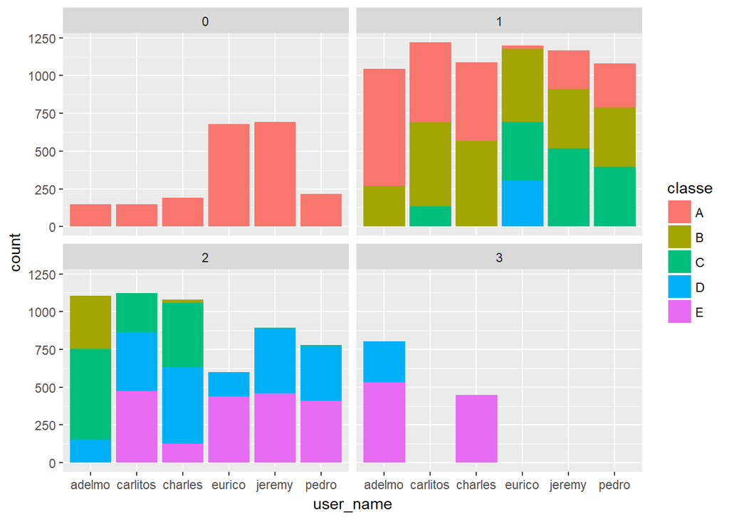

```r
ggplot(data = train, mapping = aes(x = user_name, fill = classe)) +
      facet_wrap(facets = ~mins_since_1)+
      geom_bar()
```

THen, I registered multiple cores of my computer for parallelization. I also created different data sets that included different variables. That way I tested different models with different independent variablesa.

```r
library(parallel) ; library(doParallel)
cl <- makeCluster(4)
registerDoParallel(cl)
showConnections()
```

```
##   description               class            mode  text     isopen
## 4 "output"                  "textConnection" "wr"  "text"   "opened"
## 5 "<-LAPTOP-8IHG29R4:11360" "sockconn"       "a+b" "binary" "opened"
## 6 "<-LAPTOP-8IHG29R4:11360" "sockconn"       "a+b" "binary" "opened"
## 7 "<-LAPTOP-8IHG29R4:11360" "sockconn"       "a+b" "binary" "opened"
## 8 "<-LAPTOP-8IHG29R4:11360" "sockconn"       "a+b" "binary" "opened"
##   can read can write
## 4 "no"     "yes"
## 5 "yes"    "yes"
## 6 "yes"    "yes"
## 7 "yes"    "yes"
## 8 "yes"    "yes"
```

```r
clusterEvalQ(cl, library(caret))
```

```
## [[1]]
##  [1] "caret"     "ggplot2"   "lattice"   "stats"     "graphics"
##  [6] "grDevices" "utils"     "datasets"  "methods"   "base"
##
## [[2]]
##  [1] "caret"     "ggplot2"   "lattice"   "stats"     "graphics"
##  [6] "grDevices" "utils"     "datasets"  "methods"   "base"
##
## [[3]]
##  [1] "caret"     "ggplot2"   "lattice"   "stats"     "graphics"
##  [6] "grDevices" "utils"     "datasets"  "methods"   "base"
##
## [[4]]
##  [1] "caret"     "ggplot2"   "lattice"   "stats"     "graphics"
##  [6] "grDevices" "utils"     "datasets"  "methods"   "base"
```

```r
y_index <- grep("classe", colnames(train))

#different x variables for models
y <- train[,y_index]
x1 <- train[,-c(y_index)] #all
x2 <- train[,-c(y_index, 1)] #all - index "X"
x3 <- train[,-c(y_index, 1, 3:5, 60:63)] #all - index "X" - time "raw_timestamp_part_1" "raw_timestamp_part_2" "cvtd_timestamp" "date_time" "time" "time_n"
x4 <- train[,-c(y_index, 1, 3:5, 60:64)] #all - index "X" - time - mins "mins_since_1"

names_x <- c("x1", "x2", "x3", "x4")
l_x <- list(x1, x2, x3, x4) ; names(l_x) <- names_x

clusterExport(cl, list("y"))
```

After trying different models, I decided to do random forests (these had higher accuracy). Because the train data set has a lot of observations (and the random forests would take too long), i took and stratified sample based on classe, user_name and mins_since_1 and ran the models on these subset (2,000 obs).

```r
library(dplyr)
```

```r
set.seed(144)
subset <- train %>%
      group_by(user_name, mins_since_1, classe) %>%
      sample_frac(size = 2000/nrow(train))
#grid.arrange(qplot(data = subset, x = mins_since_1, fill = classe, facets = ~user_name), qplot(data = train, x = mins_since_1, fill = classe, facets = ~user_name))

sub_ids <- train$X %in% subset$X

set.seed(114)
system.time(mods_rf <- lapply(l_x, function(x){
      train(classe~., data = data.frame("classe" = train$classe[sub_ids], x[sub_ids,]), method = "rf", prox = TRUE,
            trControl = trainControl(allowParallel =T, seeds = NA))
}))
```

```
##    user  system elapsed
##   53.09    0.79 1462.82
```

```r
preds_rf_train <- lapply(mods_rf, function(x){
      predict(x, newdata = train)
})
```

Checked the predictions in the train data set.

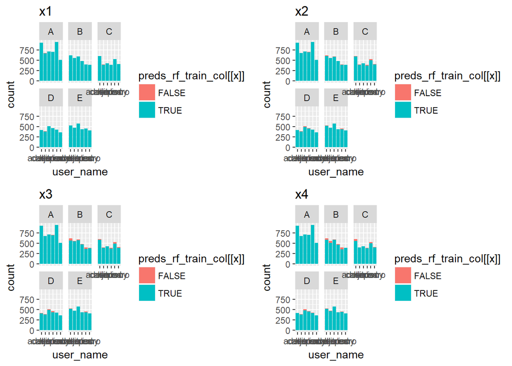

```r
preds_rf_train_col <-  lapply( 1:length(preds_rf_train), function(x){
      train$classe == preds_rf_train[[x]]
})

plot_rf_train <- lapply(1:length(l_x), function(x){
      ggplot(data = train, mapping = aes(user_name, fill = preds_rf_train_col[[x]])) + geom_bar() +
            facet_wrap(~classe) +
            ggtitle(names_x[x])
})

library(gridExtra)
grid.arrange(plot_rf_train[[1]], plot_rf_train[[2]], plot_rf_train[[3]], plot_rf_train[[4]], ncol = 2)
```

```r
cm_rf_train <- lapply(preds_rf_train, function(x){
      prop.table(confusionMatrix(x, train$classe)$table, margin = 2)*100
})

acc_rf_train <- sapply(preds_rf_train, function(x){
      confusionMatrix(x, train$classe)$overall[1]
})
```

THen, I tested the models on the validation data set.

```r
#validation

preds_rf_valid <- lapply(mods_rf, function(x){
      predict(x, newdata = validation)
})

cm_rf_valid <- lapply(preds_rf_valid, function(x){
      prop.table(confusionMatrix(x, validation$classe)$table, margin = 2)*100
})

acc_rf_valid <- sapply(preds_rf_valid, function(x){
      confusionMatrix(x, validation$classe)$overall[1]
})

cm_rf_valid # confusion matrix
```

```
## $x1
##           Reference
## Prediction           A           B           C           D           E
##          A 100.0000000   0.0000000   0.0000000   0.0000000   0.0000000
##          B   0.0000000  99.8682477   0.0000000   0.0000000   0.0000000
##          C   0.0000000   0.1317523 100.0000000   0.0000000   0.0000000
##          D   0.0000000   0.0000000   0.0000000  99.5334370   0.0000000
##          E   0.0000000   0.0000000   0.0000000   0.4665630 100.0000000
##
## $x2
##           Reference
## Prediction          A          B          C          D          E
##          A 99.3727599  0.6587615  0.0000000  0.0000000  0.0000000
##          B  0.3584229 98.6824769  1.9005848  0.0000000  0.0000000
##          C  0.2688172  0.3952569 97.2222222  1.7107309  0.0000000
##          D  0.0000000  0.2635046  0.8771930 98.2892691  1.2482663
##          E  0.0000000  0.0000000  0.0000000  0.0000000 98.7517337
##
## $x3
##           Reference
## Prediction          A          B          C          D          E
##          A 99.1935484  1.3175231  0.0000000  0.0000000  0.0000000
##          B  0.4480287 96.0474308  2.1929825  0.0000000  0.0000000
##          C  0.3584229  2.1080369 96.3450292  1.8662519  0.1386963
##          D  0.0000000  0.5270092  1.4619883 97.6671851  1.2482663
##          E  0.0000000  0.0000000  0.0000000  0.4665630 98.6130374
##
## $x4
##           Reference
## Prediction           A           B           C           D           E
##          A 100.0000000   1.9762846   0.0000000   0.3110420   0.0000000
##          B   0.0000000  94.4664032   2.3391813   0.0000000   0.0000000
##          C   0.0000000   3.4255599  96.9298246   1.7107309   0.2773925
##          D   0.0000000   0.0000000   0.7309942  97.5116641   0.8321775
##          E   0.0000000   0.1317523   0.0000000   0.4665630  98.8904300
```

```r
cbind(acc_rf_train, acc_rf_valid) #accuracy in train data set vs. accuracy in validation data set
```

```
##             acc_rf_train acc_rf_valid
## x1.Accuracy    0.9986623    0.9989804
## x2.Accuracy    0.9870692    0.9857252
## x3.Accuracy    0.9769412    0.9773133
## x4.Accuracy    0.9757309    0.9778231
```

I decided to apply only models x3 and x4 in the test set beacause they were the more parsimonious: x1 included the index variable (the data frame was ordered by classe so this would have caused overfitting) and x2 included many other variables that were highly related with mins_since_1. Both the models generated the same predictions.

```r
# ON TEST

mods <- list(mods_rf[["x3"]], mods_rf[["x4"]])
names(mods) = c("x3", "x4")

preds_test <- lapply(mods, function(x){
      predict(x, newdata = test)
})

lapply(preds_test, table)
```

```
## $x3
##
## A B C D E
## 7 8 1 1 3
##
## $x4
##
## A B C D E
## 7 8 1 1 3
```

```r
sum(preds_test[[1]] == preds_test[[2]])
```

```
## [1] 20
```

Final predictions.

```r
test$classe_pred <- as.character(preds_test[["x3"]])
cbind(test$X, test$classe_pred)
```

```
##       [,1] [,2]
##  [1,] "1"  "B"
##  [2,] "2"  "A"
##  [3,] "3"  "B"
##  [4,] "4"  "A"
##  [5,] "5"  "A"
##  [6,] "6"  "E"
##  [7,] "7"  "D"
##  [8,] "8"  "B"
##  [9,] "9"  "A"
## [10,] "10" "A"
## [11,] "11" "B"
## [12,] "12" "C"
## [13,] "13" "B"
## [14,] "14" "A"
## [15,] "15" "E"
## [16,] "16" "E"
## [17,] "17" "A"
## [18,] "18" "B"
## [19,] "19" "B"
## [20,] "20" "B"
```

```r
stopCluster(cl)
registerDoSEQ()
showConnections()
```

```
##   description class            mode text   isopen   can read can write
## 4 "output"    "textConnection" "wr" "text" "opened" "no"     "yes"
```